# Machine Learning Practice

Georgia P

## Classifying Trainee’s Quality

**Goal**: predict the manner in which trainees did the exercise, ie predict **“classe”**.

My **strategy** for approaching this project is to * begin fitting models with methods that are simple, * move on with more sophisticated & computationally intensive methods * evaluate whether my results are satisfactory or not * evaluate whether a principal components analysis can be useful * if my results need improvement and my principal components are relevant, use principal components with even more sophisticated methods to strike an appropriate accuracy- time/need for computation balance.

So here it goes …

### A: Preparatory data massage (basic)

**Creating usable data samples for training and testing**

I notice that currently my sample is full of unusable values (NAs, DIV0 etc) as well as factors that need to be numerized so as to be fed in fitting methods such as trees. Consequently I will clean-up a bit to make it usable.

```r
library(caret)
trda<-read.csv("pml-training.csv")
trains<-createDataPartition(y=trda$classe, p=0.7, list=FALSE)
trainsa<-trda[trains,]
testsa<-trda[-trains,]

#exclude NAs and keep only predictors variables. Make numerical.
nt<-trainsa[sapply(trainsa, function(trainsa) !any(is.na(trainsa)))]
ft<-nt[sapply(nt, function(nt) any(is.numeric(nt)))]
ft<-ft[,5:56]
ftpure<-ft
ft$classe<-trainsa$classe
```

### B: Prepare for Cross Validation & PCA

**Cross Validation prep**

To have a reference point of how well my model choices perform I will validate within my training set by treating it as a sample that contains both testing and training material and use cross validation to build this reference point.

First I will split my training set so as to create a sample for Cross Validation

```r
trCVi<-createDataPartition(y=ft$classe, p=0.7, list=FALSE)
trCV<-ft[trCVi,]
tsCV<-ft[-trCVi,]
```

**Principal Components Analysis** Since I have so many potential predictors it might be very useful in terms of time to process, to reduce the variability of my set, so as to make my examination faster. For that matter I analyze which variables are the most significant, thus are worth keeping.

I calculate the correlation of my variables, selecting those being above 0.75 and rebuilding a new backup training set.

```r
M<-abs(cor(ftpure[]))
diag(M)<-0
index<-which(M>0.75, arr.ind=T)

new_ft<-ftpure[, index[,1]]
new_ft$classe<-ft$classe
```

I keep these components & my backup set aside and evaluate if and when I will use them.

### C : Fit models /Fast Model Based Analysis

First I build a basic tree with rpart method on my training-training subset.

```r
rpfit<-train(trCV$classe~., data=trCV, method="rpart")
```

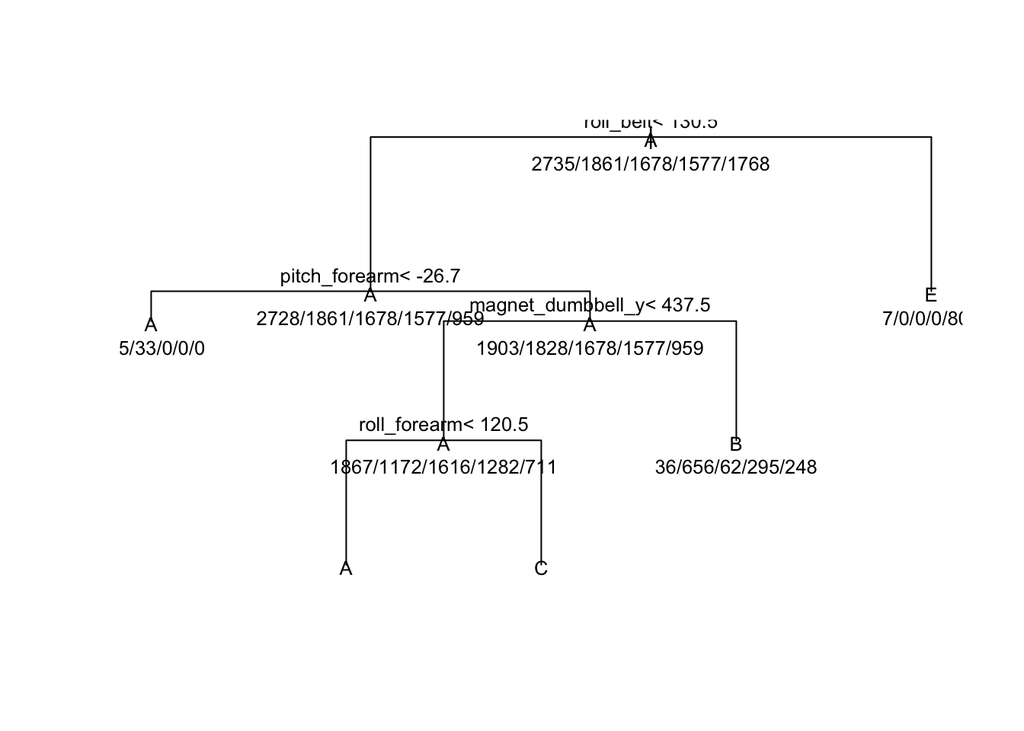

```r
plot(rpfit$finalModel)
text(rpfit$finalModel,use.n=TRUE, all=TRUE, cex=0.8 )
```

```r
rpfit$results
```

```
##           cp  Accuracy      Kappa AccuracySD    KappaSD
## 1 0.03544451 0.5181600 0.37446893 0.02399540 0.03672922
## 2 0.06134999 0.4275210 0.22910297 0.06496703 0.10833415
## 3 0.11650203 0.3380731 0.08453249 0.03883009 0.05933466
```

```r
varImp(rpfit)
```

```
## rpart variable importance
##
##   only 20 most important variables shown (out of 52)
##
##                      Overall
## pitch_forearm         100.00
## roll_belt              69.96
## roll_forearm           69.35
## magnet_dumbbell_y      51.39
## accel_belt_z           42.56
## magnet_belt_y          39.79
## yaw_belt               38.77
## total_accel_belt       34.57
## magnet_arm_x           26.44
## accel_arm_x            24.49
## roll_dumbbell          19.66
## magnet_dumbbell_x      18.77
## magnet_dumbbell_z      17.97
## accel_dumbbell_y       16.10
## roll_arm               15.14
## total_accel_dumbbell    0.00
## accel_dumbbell_z        0.00
## yaw_forearm             0.00
## accel_forearm_z         0.00
## magnet_forearm_y        0.00
```

My **model accuracy** is *not satisfactory*, so I turn to other more sophisticated methods to compare potential results.

**Random Forests** have blown up my system, so I park them to use with PCA (if needed) and turn to a less intensive method, that of **boosting**.

```r
gbmfit<-train(trCV$classe~., data=trCV, method="gbm", verbose=FALSE)
gbmfit$results
```

```
##   shrinkage interaction.depth n.minobsinnode n.trees  Accuracy     Kappa
## 1       0.1                 1             10      50 0.7534640 0.6873174
## 4       0.1                 2             10      50 0.8520116 0.8124062
## 7       0.1                 3             10      50 0.8934656 0.8650106
## 2       0.1                 1             10     100 0.8165201 0.7676637
## 5       0.1                 2             10     100 0.9021678 0.8761035
## 8       0.1                 3             10     100 0.9355135 0.9183441
## 3       0.1                 1             10     150 0.8491480 0.8090063
## 6       0.1                 2             10     150 0.9244763 0.9043675
## 9       0.1                 3             10     150 0.9535788 0.9412366
##    AccuracySD     KappaSD
## 1 0.006981523 0.008871980
## 4 0.006359473 0.008022767
## 7 0.005328700 0.006758967
## 2 0.005790386 0.007252812
## 5 0.005340076 0.006773681
## 8 0.004596084 0.005823934
## 3 0.005272528 0.006604901
## 6 0.004529927 0.005703205
## 9 0.003853769 0.004878201
```

**Accuracy** with boosting seems radically **better**, remains to be validated with my testing on the train subset.

**Can I use PCA with Random Forests to get even better results?**

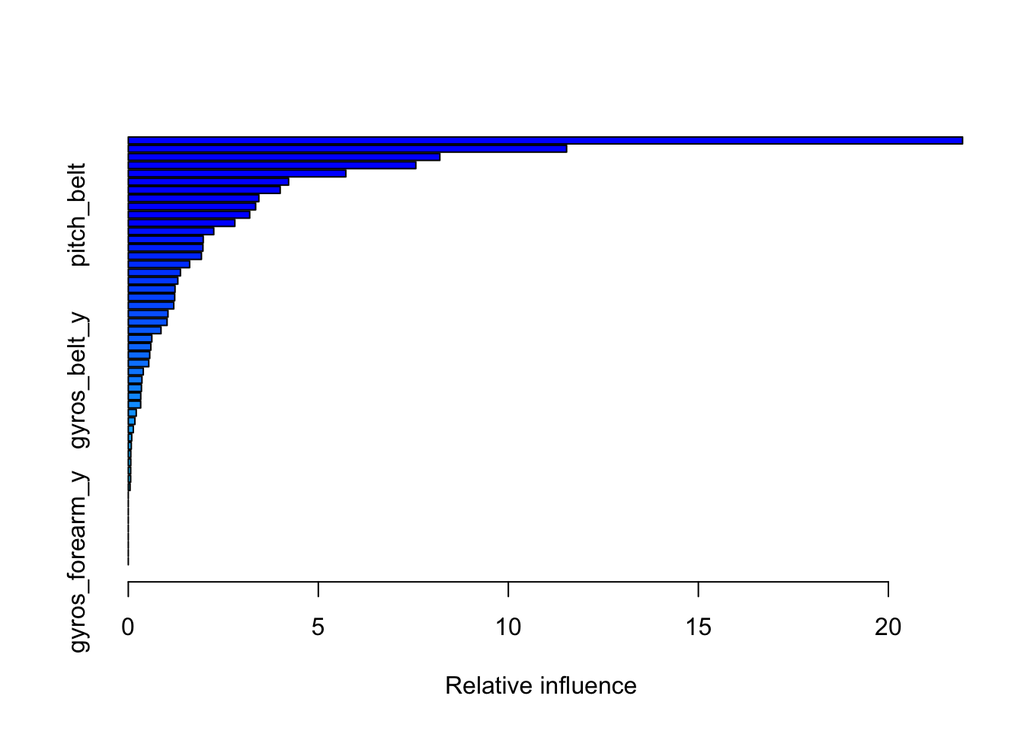

```
##                                       var     rel.inf
## roll_belt                       roll_belt 21.95181354
## pitch_forearm               pitch_forearm 11.53311129
## yaw_belt                         yaw_belt  8.19742916
## magnet_dumbbell_z       magnet_dumbbell_z  7.56546237
## magnet_dumbbell_y       magnet_dumbbell_y  5.72356086
## magnet_belt_z               magnet_belt_z  4.21802828
## roll_forearm                 roll_forearm  3.99680970
## roll_dumbbell               roll_dumbbell  3.43557408
## gyros_belt_z                 gyros_belt_z  3.35085770
## pitch_belt                     pitch_belt  3.19411123
## accel_forearm_x           accel_forearm_x  2.80368410
## gyros_dumbbell_y         gyros_dumbbell_y  2.24910120
## accel_dumbbell_x         accel_dumbbell_x  1.97176657
## yaw_arm                           yaw_arm  1.96424949
## accel_dumbbell_y         accel_dumbbell_y  1.92449717
## magnet_forearm_z         magnet_forearm_z  1.61363581
## magnet_forearm_x         magnet_forearm_x  1.37207032
## magnet_belt_y               magnet_belt_y  1.30322185
## accel_dumbbell_z         accel_dumbbell_z  1.22990496
## magnet_arm_z                 magnet_arm_z  1.22129546
## magnet_belt_x               magnet_belt_x  1.19615012
## accel_forearm_z           accel_forearm_z  1.04403646
## magnet_dumbbell_x       magnet_dumbbell_x  1.02044865
## accel_belt_z                 accel_belt_z  0.86070641
## magnet_arm_x                 magnet_arm_x  0.61955225
## magnet_arm_y                 magnet_arm_y  0.59281293
## gyros_arm_y                   gyros_arm_y  0.56417687
## total_accel_dumbbell total_accel_dumbbell  0.53919229
## roll_arm                         roll_arm  0.39467548
## gyros_belt_y                 gyros_belt_y  0.35942160
## accel_arm_x                   accel_arm_x  0.34613584
## gyros_dumbbell_x         gyros_dumbbell_x  0.32776669
## total_accel_forearm   total_accel_forearm  0.32577493
## pitch_dumbbell             pitch_dumbbell  0.20934184
## accel_forearm_y           accel_forearm_y  0.17416230
## yaw_forearm                   yaw_forearm  0.13270704
## total_accel_arm           total_accel_arm  0.09046308
## total_accel_belt         total_accel_belt  0.07876474
## gyros_forearm_z           gyros_forearm_z  0.06591215
## accel_arm_z                   accel_arm_z  0.06566781
## gyros_dumbbell_z         gyros_dumbbell_z  0.06284998
## magnet_forearm_y         magnet_forearm_y  0.06209706
## yaw_dumbbell                 yaw_dumbbell  0.04699835
## gyros_belt_x                 gyros_belt_x  0.00000000
## accel_belt_x                 accel_belt_x  0.00000000
## accel_belt_y                 accel_belt_y  0.00000000
## pitch_arm                       pitch_arm  0.00000000
## gyros_arm_x                   gyros_arm_x  0.00000000
## gyros_arm_z                   gyros_arm_z  0.00000000
## accel_arm_y                   accel_arm_y  0.00000000
## gyros_forearm_x           gyros_forearm_x  0.00000000
## gyros_forearm_y           gyros_forearm_y  0.00000000
```

```r
summary(gbmfit)
```

These are the boosting predictors & their importance. I cross-check my PCA components and notice that they might be oversimplified predictor, missing a few with quite high importance, so I don’t opt for this combination now.

### D : Evaluate my model /predicting its error

I am using my training-testing subset to evaluate my potential error, or “I know what you did with last model”

```r
prepart<-predict(rpfit,tsCV) ; preboost<-predict(gbmfit, tsCV)
correctpart <- prepart==tsCV$classe ; correctgbm <- preboost==tsCV$classe

#Evaluate RSME
errb1<- table(correctpart, tsCV$classe)
err1<-0 ;dia1<- 0
for (i in 1: 5 ){err1<- err1+(errb1[1,i]*errb1[1,i]) ; dia1<- dia1+ errb1[1,i]+errb1[2,i]}
RMSE1<-sqrt(err1/dia1)

errb2<- table(correctgbm, tsCV$classe)
err2<-0 ;dia2<- 0
for (i in 1: 5 ){err2<- err2+(errb2[1,i]*errb2[1,i]) ; dia2<- dia2+ errb2[1,i]+errb2[2,i]}
RMSE2<-sqrt(err2/dia2)
```

### E : Predicting on the test set.

Having selected the boosting model as the one with best accuracy & radically better RMSE of ~0.9 vs ~11, I use it for predictions on my test set

```r
#PREDICT
gwhat<-predict(gbmfit,testsa)
correct<- gwhat==testsa$classe
table(gwhat, testsa$classe)
```

```
##
## gwhat    A    B    C    D    E
##     A 1637   48    0    3    1
##     B   25 1051   30    4   15
##     C    7   39  978   33   12
##     D    4    1   16  910   22
##     E    1    0    2   14 1032
```

```r
#Evaluate RSME
errb<- table(correct, testsa$classe)
err<-0 ;dia<- 0
for (i in 1: 5 ){err<- err+(errb[1,i]*errb[1,i]) ; dia<- dia+ errb[1,i]+errb[2,i]}
RMSE<-sqrt(err/dia)
```

RMSE **1.6912489** seems pretty good, so approved for launching & identifying quality trainees.